# The salinity in different areas

Project 3

510528584

# 1 Recommendaton

The question I studied was whether there was a difference in salinity between “Mackay Marina Wall” and “Woongarra Hoffman’s Rock” station area.So, My client groups for this report are environmentalists and A group concerned with soil and water conservation.

After setting the research questions, I put forward the hypothesis that there is no difference in salinity between the two regions, and ensure that these data are suitable for data analysis. Finally, after a series of calculations, I came to my conclusion that there was no significant difference in salinity between the two regions.

Because high salinity may be caused the Agricultural production, Water quality or Flood risk, we should avoid it. I think we can use Precipitation enhancement to dilute the salinity of seawater. Or control the temperature of the area. Even, we can set up windbreaks around the area.

Finally, according to the data analysis of National Geographic, more and more areas of the world are affected by high salinity, with an estimated loss of $800 million annualy, and rising. So we should avoid global warming that high temperatures would lead to increased salinity. Such as green travel and other ways to reduce carbon dioxide cooking.

# 2 Evidence

## 2.1 IDA

```r
# Read in your data
## Option 3: Great Barrier Reef Chlorophyll Monitoring
gbr = read.csv("/Users/wangzhongxu/data_rmd/rmd/p3/GBR.csv")
```

```r
## Quick snapshot
dim(gbr)
```

```
## [1] 19174    14
```

```r
str(gbr)
```

```
## 'data.frame':    19174 obs. of  14 variables:
##  $ STATION_NAME  : chr  "Hook Passage" "Hook Passage" "Hook Passage" "Hook Passage" ...
##  $ TRANSECT      : chr  "Whitsundays" "Whitsundays" "Whitsundays" "Whitsundays" ...
##  $ STATION_ID    : int  228 228 228 228 229 229 229 229 227 227 ...
##  $ SAMPLE_TIME   : chr  "15/1/09 9:39" "15/1/09 9:39" "15/1/09 9:39" "15/1/09 9:39" ...
##  $ LATITUDE      : num  -20.2 -20.2 -20.2 -20.2 -19.8 ...
##  $ LONGITUDE     : num  149 149 149 149 149 ...
##  $ SECCHI_DEPTH  : num  NA NA NA NA NA NA NA NA NA NA ...
##  $ ACOUSTIC_DEPTH: num  25 25 25 25 64 64 64 64 25 25 ...
##  $ REPLICATE_DESC: chr  "A1" "A2" "B1" "B2" ...
##  $ TEMPERATURE   : num  29 29 29 29 29.5 29.5 29.5 29.5 29 29 ...
##  $ SALINITY      : num  38 38 38 38 38 38 38 38 38 38 ...
##  $ SAMPLE_DEPTH  : num  25 25 25 25 64 64 64 64 25 25 ...
##  $ CHL_A         : num  0.61 0.67 0.64 0.69 0.55 0.47 0.47 0.5 0.49 0.53 ...
##  $ TRICHODESMIUM : chr  "Absent" "Absent" "Absent" "Absent" ...
```

```r
head(gbr)
```

```
##   STATION_NAME    TRANSECT STATION_ID  SAMPLE_TIME LATITUDE LONGITUDE
## 1 Hook Passage Whitsundays        228 15/1/09 9:39  -20.210   148.905
## 2 Hook Passage Whitsundays        228 15/1/09 9:39  -20.210   148.905
## 3 Hook Passage Whitsundays        228 15/1/09 9:39  -20.210   148.905
## 4 Hook Passage Whitsundays        228 15/1/09 9:39  -20.210   148.905
## 5    Line Reef Whitsundays        229 15/1/09 9:39  -19.756   149.140
## 6    Line Reef Whitsundays        229 15/1/09 9:39  -19.756   149.140
##   SECCHI_DEPTH ACOUSTIC_DEPTH REPLICATE_DESC TEMPERATURE SALINITY SAMPLE_DEPTH
## 1           NA             25             A1        29.0       38           25
## 2           NA             25             A2        29.0       38           25
## 3           NA             25             B1        29.0       38           25
## 4           NA             25             B2        29.0       38           25
## 5           NA             64             A1        29.5       38           64
## 6           NA             64             A2        29.5       38           64
##   CHL_A TRICHODESMIUM
## 1  0.61        Absent
## 2  0.67        Absent
## 3  0.64        Absent
## 4  0.69        Absent
## 5  0.55        Absent
## 6  0.47        Absent
```

The background of this dataset is the Reef Plan Marine Monitoring Programs (Reef Plan MMP) made by the Australian Institute of Marine Science, which is a long-term water quality monitoring program.

This dataset consisted by 19174 obs. of 14 variables (5 qualitative and 9 quantitative variables), which includes water quality data (SALINITY, concentration of Chlorophyll, etc) in each area, as well as the temperature, water depth, latitude and longitude of the area. Also, it gives the sample time, ID of station name and transect name.

```r
summary(gbr$SALINITY)
```

```
##    Min. 1st Qu.  Median    Mean 3rd Qu.    Max.    NA's
##   1.026  35.000  36.000  36.068  37.000  44.660   17864
```

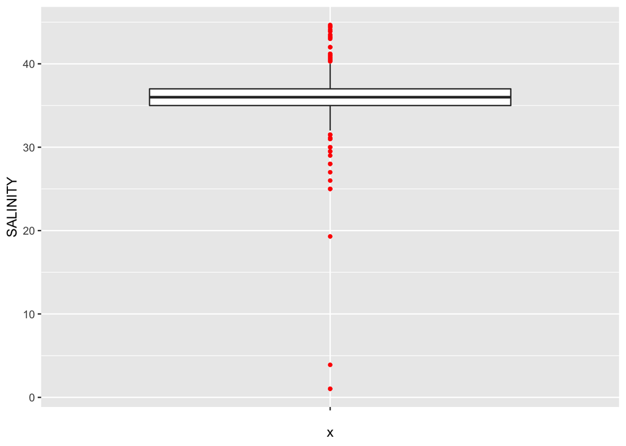

```r
library(ggplot2)

p = ggplot(data=gbr, aes(x="", y= SALINITY))
p + geom_boxplot(outlier.colour = "red", outlier.size = 1)
```

1, For the “SALINITY” data, it unit is “g/Kg”. The mean is 36,068, But the some values are very extreme. This box plot are same as the data of numerical analysis. But in this box plot, there is a skewed on it. Therefore, this may lead to some issue on data analysis. So, I will choose part of data to using. Also, this box plot is not average

```r
summary(gbr$TEMPERATURE)
```

```
##    Min. 1st Qu.  Median    Mean 3rd Qu.    Max.    NA's
##   16.00   24.00   25.70   25.39   27.30   38.00   17900
```

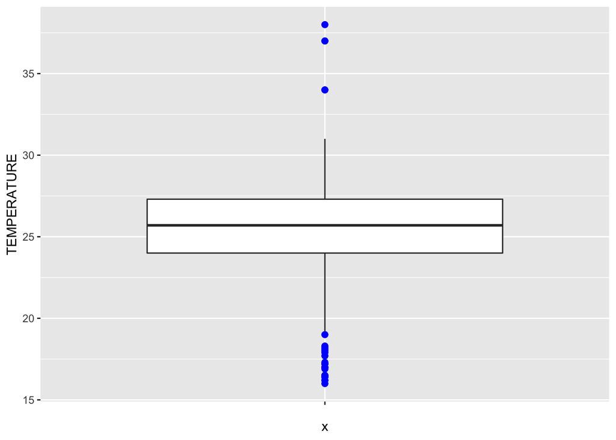

```r
p = ggplot(data=gbr, aes(x="", y= TEMPERATURE))
p + geom_boxplot(outlier.colour = "blue", outlier.size = 2)
```

```r
table(gbr$STATION_NAME)
```

## 2.2 Research Question:

> Is there no difference between the salinity(g/Kg) of seawater in the station that names “Mackay Marina Wall” and “Woongarra Hoffman’s Rocks”.

```r
# use the ggplot2 of tidverse package
library(tidyverse)
```

```r
a1 = gbr %>%
  select(STATION_NAME, SALINITY)%>%
  drop_na()  # drop the  na value

a1
```

```r
b1 = c("Mackay Marina Wall", "Woongarra Hoffman's Rocks")
a2 = filter(a1, STATION_NAME == b1 )
a2
```

```
##                 STATION_NAME SALINITY
## 1         Mackay Marina Wall    38.00
## 2         Mackay Marina Wall    40.00
## 3         Mackay Marina Wall    38.00
## 4         Mackay Marina Wall    32.00
## 5         Mackay Marina Wall    40.00
## 6         Mackay Marina Wall    36.00
## 7         Mackay Marina Wall    39.00
## 8  Woongarra Hoffman's Rocks    36.00
## 9         Mackay Marina Wall    36.00
## 10 Woongarra Hoffman's Rocks    36.50
## 11        Mackay Marina Wall    36.00
## 12 Woongarra Hoffman's Rocks    35.00
## 13        Mackay Marina Wall    33.00
## 14        Mackay Marina Wall    40.00
```

[output cut: 19 more lines]

Because my research question is focus on the two station name. So, I will further process the data set “a1” so that it contains only the two station names I need. After a series of sort, I get the final data set “a2”.

### 2.2.1 HAPTC

Assume that：

$\mu_1$ = mean salinity of station “Mackay Marina Wall”

$\mu_2$ = mean salinity of station “Woongarra Hoffman’s Rocks”

I used standard value is “0.05”

**Hypothesis**

H0：There is no difference between the salinity(g/Kg) in the station “Mackay Marina Wall” and “Woongarra Hoffman’s Rocks”.

($\mu_1$ = $\mu_2$)

H1：There have a difference between the salinity(g/Kg) the station “Mackay Marina Wall” and “Woongarra Hoffman’s Rocks”.

($\mu_1$ != $\mu_2$)

**Assumption**

1. The two samples are independent

I used Google Map to search for the detailed addresses and found that they belong to different area and they’re very far apart. So these two sample are independent.

2. The 2 population are Normal.

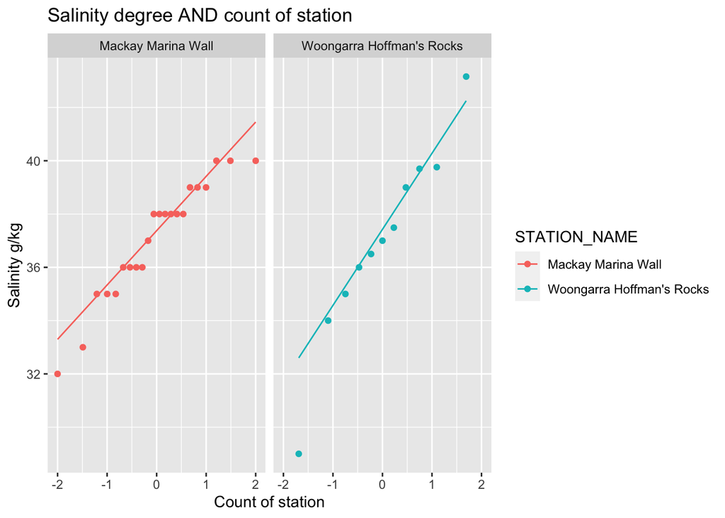

```r
a2 %>%ggplot() +
  geom_qq(aes(sample= SALINITY, color = STATION_NAME))+
  geom_qq_line(aes(sample=SALINITY, color = STATION_NAME))+
  labs(x = "Count of station", y = "Salinity g/kg", title = "Salinity degree AND count of station")+
  facet_wrap(~STATION_NAME)
```

```r
# qqplot
```

Firstly, I created the plot to check whether it is normally. For this diagram, it is suitable for assumption.

But there are still some defects, because some data intensive and outlier on it. So I’m going to check the test value.

```r
a2_station_1 = filter(a2, STATION_NAME == "Mackay Marina Wall")
shapiro.test(a2_station_1$SALINITY)
```

```
##
##  Shapiro-Wilk normality test
##
## data:  a2_station_1$SALINITY
## W = 0.92864, p-value = 0.1149
```

```r
a2_station_2 = filter(a2, STATION_NAME == "Woongarra Hoffman's Rocks")
shapiro.test(a2_station_2$SALINITY)
```

```
##
##  Shapiro-Wilk normality test
##
## data:  a2_station_2$SALINITY
## W = 0.96042, p-value = 0.7769
```

Then, I make the two Shapiro-Wilk Test to check whether it is Normally.

The answer are both fine. It means that we can guess the 2 population are Normal.

```r
# Use hrbrthemes and ggplot package
library(hrbrthemes)
library(ggplot2)
```

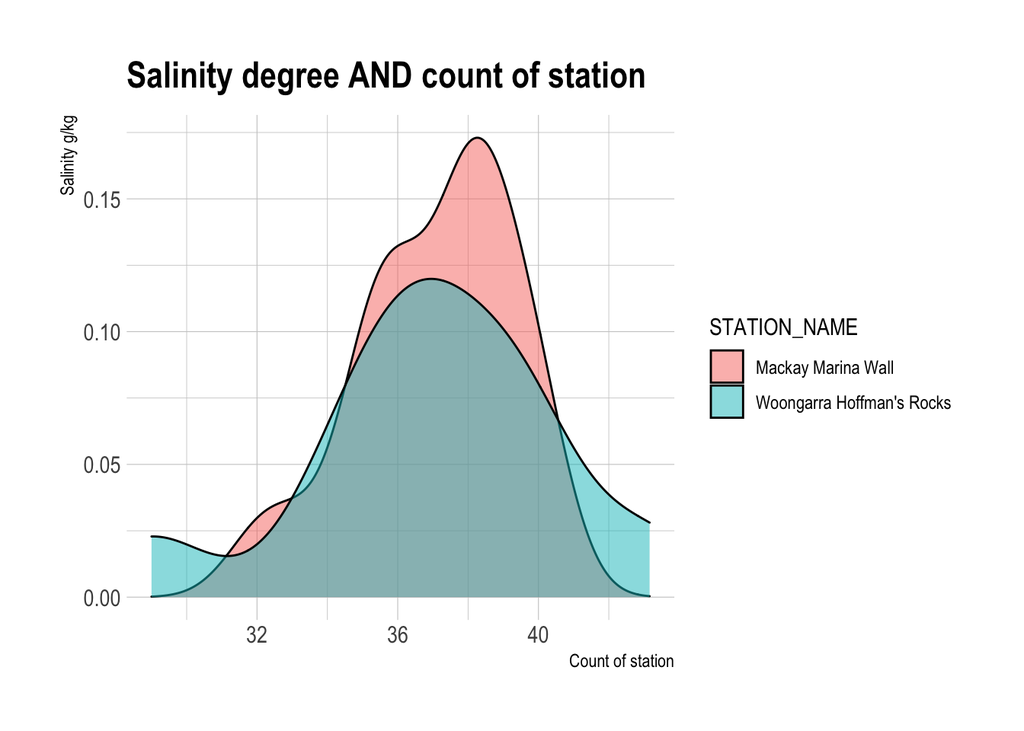

```r
a2 %>%
  ggplot(aes(x=SALINITY, fill=STATION_NAME)) +
  geom_density(alpha=0.5) +
  labs(x="Count of station", y="Salinity g/kg", title = "Salinity degree AND count of station", colors())+
  theme_ipsum()
```

Finally, I draw the normal curve directly. It seems very normally, but for “Mackay Marina Wall” line, it has some fluctuations on the left side.

But, in general, this diagram should be all right

3. The 2 populations have equal spread (SD/variance).

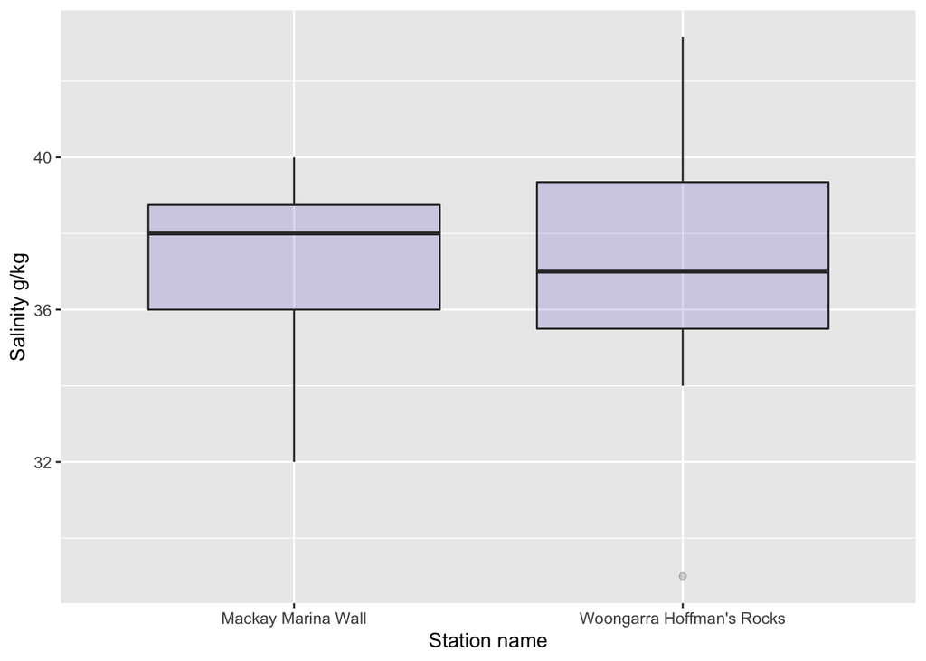

```r
# ggplot box plot
p = ggplot(a2, aes(x=STATION_NAME, y= SALINITY, fill= STATION_NAME))
p + geom_boxplot(fill="slateblue", alpha=0.2)+
  ylab("Salinity g/kg")+
  xlab("Station name")
```

For this two box plot, I think the interval length of the two plots is very similar, although the one on the left is slightly different. In general, this graph is a little symmetric, but they all have certain areas of focus.

So, I will do a Test to ensure the accuracy that the 2 populations have equal spread.

```r
# Use car package
library(car)
```

```r
leveneTest(SALINITY ~ STATION_NAME, data = a2)
```

```
## Levene's Test for Homogeneity of Variance (center = median)
##       Df F value Pr(>F)
## group  1  1.5049 0.2292
##       31
```

```r
#numerical~categorical, data
```

As we can see, the outcome of test is fine, So it can show the 2 populations have equal spread.

**Test Statistic**

```r
t.test(SALINITY ~ STATION_NAME, data = a2, var.equal = TRUE, conf.level = 0.95)
```

```
##
##  Two Sample t-test
##
## data:  SALINITY by STATION_NAME
## t = 0.12372, df = 31, p-value = 0.9023
## alternative hypothesis: true difference in means is not equal to 0
## 95 percent confidence interval:
##  -1.956709  2.209436
## sample estimates:
##        mean in group Mackay Marina Wall mean in group Woongarra Hoffman's Rocks
##                                37.09091                                36.96455
```

Firstly, I check the T-test for 2 sample

I get the t = 0.12372, p-value = 0.9023.

So, *Test Statistic* = (Observed mean - population mean)/SE = 0.12372

**P-Value** From above T-test outcome, the p-value is:

*p-Value* = 0.9023 > 0.05

**Conclusion**

# 3 Other Evidence

1, Salinity. (n.d.). Retrieved May 28, 2021, from https://science.nasa.gov/earth-science/oceanography/physical-ocean/salinity

2, Salinity. (2021, May 21). Retrieved May 28, 2021, from https://en.wikipedia.org/wiki/Salinity

# 4 References

1, Queensland;, C. (2013, October 01). Impacts of salinity. Retrieved May 28, 2021, from https://www.qld.gov.au/environment/land/management/soil/salinity/impacts

2, Untitled document. (n.d.). Retrieved May 28, 2021, from http://www.aquatic.uoguelph.ca/oceans/PacificOceanWeb/NPProperties/Salinity.htm#:~:text=Three%20major%20factors%20influence%20salinity,ocean%2C%20diluting%20its%20salt%20concentration.